# Decomposed annual coral-cover change

Transferring bleaching modifiers into recovery and disturbance-loss prediction

## Decision

The decomposed model improves on treating annual change as one unconstrained response. It predicts recovery relative to available reef space and loss relative to current coral cover, then combines them into a bounded next-cover estimate.

There is not one winner for every operational use:

- Before a genuinely novel event is observed, the **core decomposition** is safest (forward 2024–2025 RMSE 10.05 percentage points; recent-year RMSE 8.40).
- For spatial prediction after early observations from an event are available, the **modifier-rich model** is strongest across unseen reefs (RMSE 6.76; predictive R2 0.209).
- For reef-blocked 2024, transferring the restricted relative-mortality observations into the loss learner gives the best RMSE (8.59) and predicts mean change as -4.52 points, compared with -5.89 observed.

The severe tail remains underpredicted. For 53 reef-blocked 2024 transitions with losses of at least 10 points, mean observed change is -21.58 points and the mortality-augmented prediction is -11.14. This is useful progress, but not yet adequate for the final GBR-wide product.

## Model structure

The predictive transition is

$$C_{t+1} = C_t + (1-C_t)G_t - C_tL_t,$$

where $G_t$ is expected net gain relative to available space and $L_t$ is expected net loss relative to existing cover. Each has a Bernoulli occurrence model and a bounded positive-magnitude model.

These components are inferred from **net annual change**. Annual snapshots do not independently observe gross growth and mortality when both happened in the same interval.

Three loss formulations were tested:

1. Structural state, nonlinear DHW and Acropora.
2. The same model plus thermal history/novelty, Secchi/cloud, water colour, coastal rainfall, wind/calm, cyclone waves, COTS and explicit DHW interactions.
3. The modifier-rich model additionally trained with the restricted, bleaching-attributed relative-mortality responses. Auxiliary rows obey the same year or reef exclusions as each annual fold.

Rainfall and water colour remain exposure proxies, not measured salinity. Cyclone waves and COTS remain separate mechanisms.

## Matched validation

| Model | Validation | RMSE (pp) | Predictive R2 | Direction accuracy | Severe-loss MAE (pp) | Severe underprediction (pp) |
| --- | --- | --- | --- | --- | --- | --- |
| Change BRT | Forward 2024-2025 | 12.06 | -0.357 | 54.9% | 17.93 | 15.68 |
| Change BRT | Recent year held out | 9.16 | -0.120 | 55.8% | 17.36 | 16.23 |
| Change BRT | Unseen reefs | 6.98 | 0.156 | 60.6% | 13.73 | 13.23 |
| Core decomposed BRT | Forward 2024-2025 | 10.05 | 0.058 | 60.8% | 18.05 | 17.62 |
| Core decomposed BRT | Recent year held out | 8.40 | 0.058 | 56.5% | 16.87 | 16.78 |
| Core decomposed BRT | Unseen reefs | 7.02 | 0.146 | 59.7% | 14.50 | 14.41 |
| Growth/environment LM | Forward 2024-2025 | 10.62 | -0.053 | 55.8% | 19.08 | 19.08 |
| Growth/environment LM | Recent year held out | 8.54 | 0.027 | 53.5% | 16.81 | 16.81 |
| Growth/environment LM | Unseen reefs | 7.21 | 0.101 | 57.5% | 14.88 | 14.88 |
| Modifier-rich decomposed BRT | Forward 2024-2025 | 10.94 | -0.117 | 53.4% | 18.93 | 18.63 |
| Modifier-rich decomposed BRT | Recent year held out | 8.52 | 0.032 | 58.7% | 17.22 | 17.10 |
| Modifier-rich decomposed BRT | Unseen reefs | 6.76 | 0.209 | 62.1% | 13.74 | 13.51 |
| Mortality-augmented decomposed BRT | Forward 2024-2025 | 11.22 | -0.174 | 52.5% | 19.30 | 17.85 |
| Mortality-augmented decomposed BRT | Recent year held out | 8.56 | 0.021 | 58.4% | 17.24 | 16.06 |
| Mortality-augmented decomposed BRT | Unseen reefs | 6.79 | 0.202 | 62.1% | 13.81 | 13.36 |
| Persistence | Forward 2024-2025 | 11.13 | -0.155 | 0.6% | 21.00 | 21.00 |
| Persistence | Recent year held out | 8.66 | -0.001 | 0.2% | 19.71 | 19.71 |
| Persistence | Unseen reefs | 7.61 | -0.001 | 0.1% | 18.40 | 18.40 |

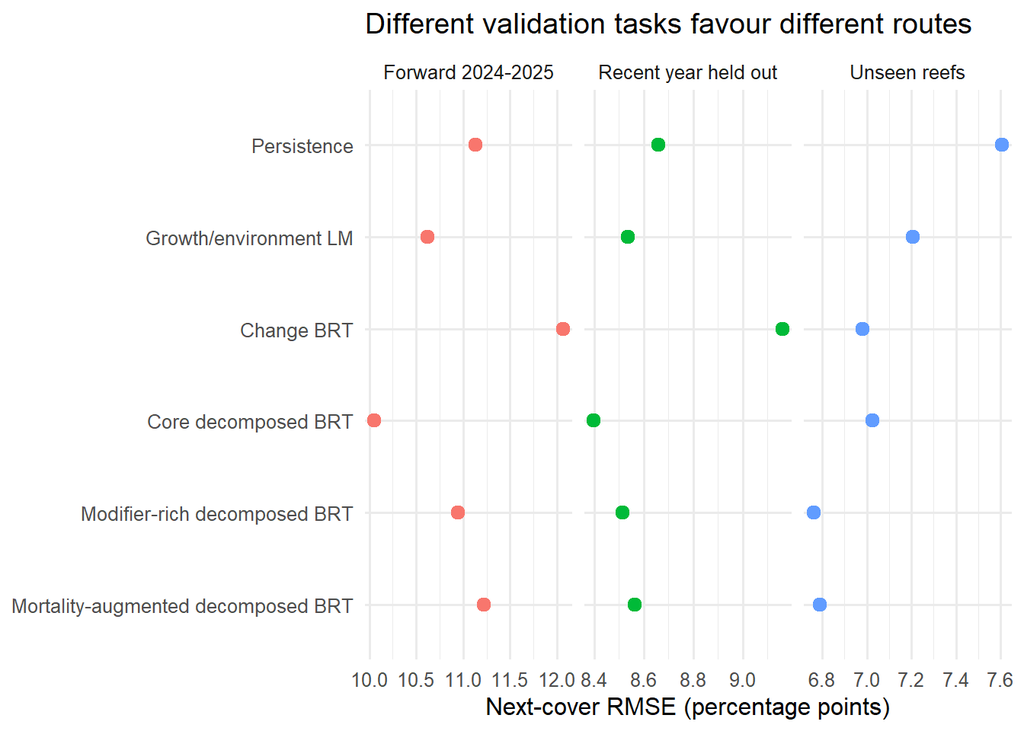

An equal modifier-rich/mortality-augmented blend has the lowest overall unseen-reef RMSE (6.74), but its weight has not yet been cross-fitted. It is a sensitivity, not a promoted ensemble, and it is weaker than the core model when 2024 is entirely absent.

| Validation | RMSE (pp) | Predictive R2 | Severe-loss MAE (pp) |
| --- | --- | --- | --- |
| forward_2024_2025 | 11.00 | -0.129 | 19.10 |
| recent_year_holdout | 8.48 | 0.040 | 17.18 |
| reef_blocked_5fold | 6.74 | 0.213 | 13.69 |

## The 2024 event

| Model | Observed mean (pp) | Predicted mean (pp) | Predicted gain (pp) | Predicted loss (pp) | RMSE (pp) | Severe observed (pp) | Severe predicted (pp) |
| --- | --- | --- | --- | --- | --- | --- | --- |
| Core decomposed BRT | -5.89 | -4.06 | 1.32 | 5.38 | 9.06 | -21.58 | -9.12 |
| Modifier-rich decomposed BRT | -5.89 | -3.97 | 1.25 | 5.22 | 9.11 | -21.58 | -9.33 |
| Mortality-augmented decomposed BRT | -5.89 | -4.52 | 1.20 | 5.72 | 8.59 | -21.58 | -11.14 |

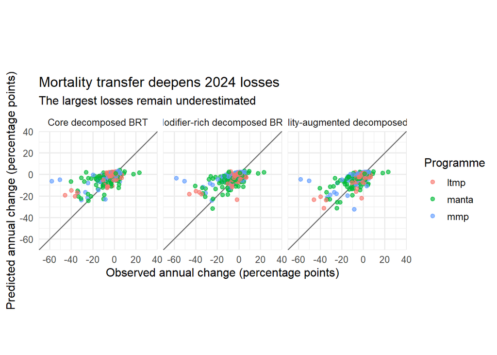

For severe 2024 cases, the rich covariates alone add only 0.21 points of loss on average and improve 43% of reefs. The restricted mortality response adds a further 1.81 points of loss and improves 64%. Response transfer helps; simply adding more covariates is insufficient.

| Class | N | Rich minus core (pp) | Rich improves | Auxiliary minus rich (pp) | Auxiliary improves |
| --- | --- | --- | --- | --- | --- |
| Other transitions | 181 | 0.18 | 56.4% | -0.18 | 51.9% |
| Loss >=10 pp | 53 | -0.21 | 43.4% | -1.81 | 64.2% |

## Remaining severe misses

| Reef | Programme | Observed | Core | Rich | Augmented | DHW | Acropora | WQC | Annotation |
| --- | --- | --- | --- | --- | --- | --- | --- | --- | --- |
| Snapper Reef (16-006) | mmp | -57.9 | -6.4 | -3.8 | -4.8 | 6.9 | 14% | 0.90 | Jasper Cyclone Jasper, flood waters at 2.0 m only, coral bleaching at 5.0 m only \| flood waters, Cyclone Jasper |
| Snapper Reef (16-006) | mmp | -50.3 | -5.2 | -6.4 | -6.0 | 6.9 | 23% | 0.90 | Jasper Cyclone Jasper, flood waters at 2.0 m only, coral bleaching at 5.0 m only \| flood waters, Cyclone Jasper |
| North Direction Reef (14-143) | manta | -40.2 | -6.6 | -10.8 | -13.0 | 6.2 | 44% | 0.02 | DHW 6.23 aerial bl 5 coral bleaching |
| Mackay Reef (16-015) | manta | -26.0 | 1.9 | -1.9 | -3.6 | 3.8 | 11% | 0.07 | DHW 4.03 coral bleaching, Cyclone Jasper, flood waters |
| One Tree Island Reef (23-055a) | ltmp | -45.6 | -19.4 | -18.4 | -23.6 | 11.6 | 92% | 0.05 | DHW 11 coral bleaching, coral disease |
| Linnet Reef (14-126) | manta | -30.6 | -3.2 | -13.1 | -11.5 | 6.7 | 63% | 0.54 | DHW 6.73 coral bleaching |
| Broomfield Reef (23-048) | ltmp | -39.6 | -15.1 | -15.7 | -20.8 | 11.6 | 86% | 0.04 | Aerial bl 5 2024 DHW 11.6 coral bleaching, unknown storm |
| Hoskyn Islands Reef (23-080) | manta | -33.9 | -15.2 | -12.5 | -16.9 | 11.3 | 26% | 0.05 | DHW 11.48 coral bleaching |
| U/N Reef (21-187) | manta | -27.6 | -6.8 | -4.8 | -11.3 | 7.2 | 31% | 0.00 | NA |
| Fitzroy Island Reef (No 1) (16-054a) | mmp | -24.2 | -8.1 | -9.7 | -8.0 | 7.7 | 59% | 0.53 | partial bleaching during bleaching surveys Feb24 \| bleaching observed during targetted bleaching surveys coral bleaching at 2.0 m only \| coral bleaching at 2.0 m only, Cyclone Jasper |
| U/N Reef (21-529) | manta | -23.9 | -3.5 | -3.9 | -8.0 | 7.2 | 39% | 0.00 | Aerial bl 5 2024 DHW 7.19 2024 coral bleaching |
| Low Islands Reef (16-028) | manta | -21.3 | -3.9 | -2.6 | -5.8 | 6.4 | 7% | 0.56 | Jasper Jasper Cyclone Jasper, flood waters, coral bleaching |
| Tobias Spit (17-009a) | mmp | -19.5 | -0.7 | -4.7 | -5.1 | 6.3 | 27% | 0.75 | clear depth limit to level of mortality flood waters at 2.0 m only, Cyclone Jasper at 2.0 m only, crown-of-thorns starfish at 5.0 m only |
| Orpheus (Goolboddi) Island Reef (No 5) (18-049e) | mmp | -14.6 | -5.5 | -2.4 | -2.2 | 5.5 | 92% | 0.28 | bleaching observed during targetted bleaching surveys coral bleaching, Cyclone Kirrily |
| Normanby-Mabel Reef (17-012) | mmp | -13.5 | -5.0 | -6.0 | -1.6 | 6.4 | 69% | 0.57 | COTS seen this year and last, but also BrB disease \| combination of flood, COTS, minor bleachng crown-of-thorns starfish \| unknown at 2.0 m only |

Snapper remains the dominant miss: observed losses of 50–58 points are predicted as only 5–6 despite very high water-colour exposure and explicit Jasper/flood annotations. North Direction, Mackay, Linnet, One Tree and Broomfield improve to varying degrees, but none is fully captured.

Residual is observed minus predicted change, so a negative value denotes underprediction of loss. Among severe 2024 rows, greater calm exposure, rainfall and water colour are associated with more negative residuals. The positive DHW association means the worst misses concentrate among severe losses at moderate rather than extreme DHW. This is consistent with an incompletely represented freshwater/calm mechanism; it is diagnostic, not causal evidence.

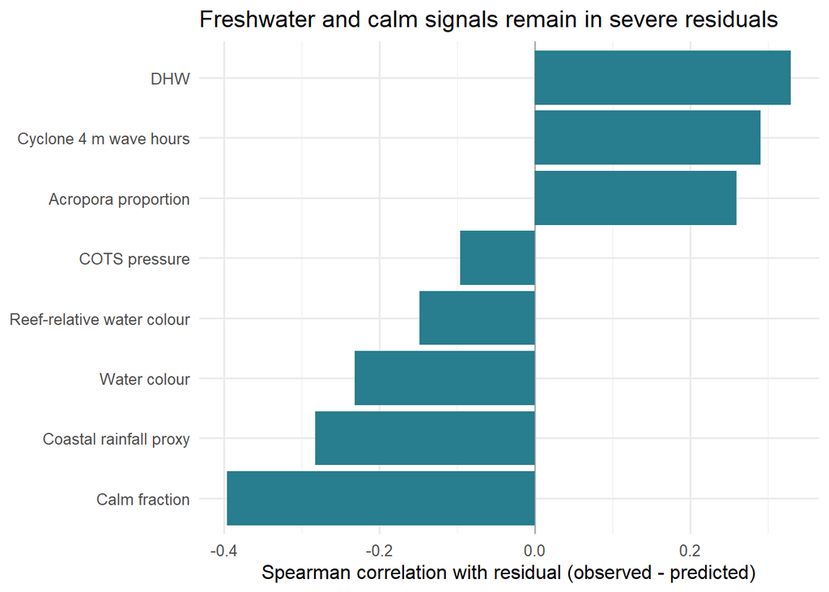

The RRN cyclone-wave value is zero at several Jasper-annotated northern reefs. It should remain in the model, but cannot alone represent Jasper or floodwater exposure.

## Loss-variable influence

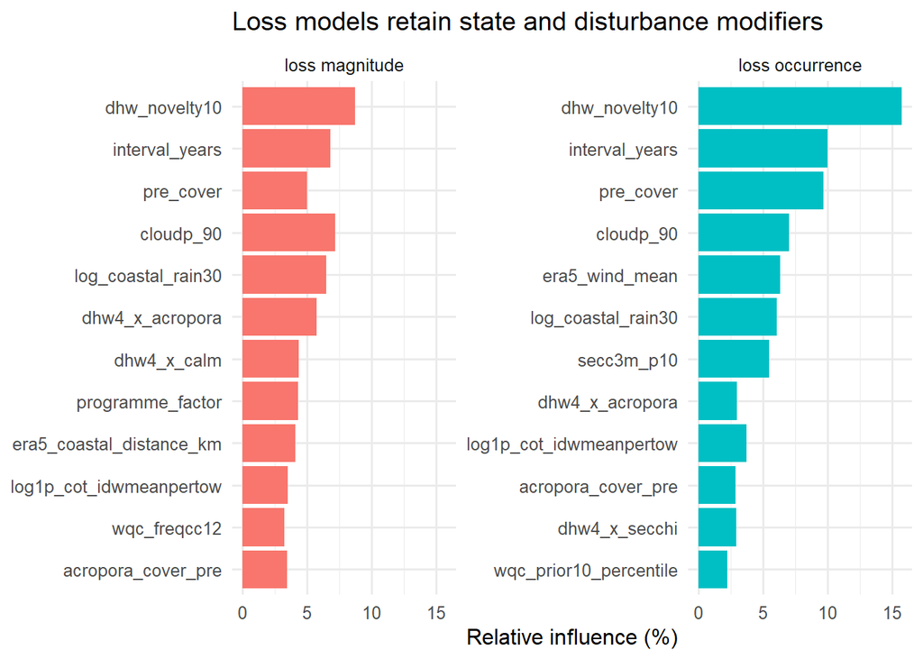

## Next fit

The next Bayesian/state-space fit should:

1. Use beta magnitude and binomial occurrence responses for gain and loss with programme-specific observation layers.
2. Retain the modifier-rich and mortality-augmented BRTs as ensemble members.
3. Evaluate stronger tail response to DHW interactions with rainfall, water colour and calm against reef-blocked 2024 severe loss, not overall RMSE only.
4. Keep field annotations diagnostic rather than operational predictors.
5. Add a broader community-state variable when available; Acropora alone does not identify reefs dominated by fast-growing weedy taxa.

Operationally, use the core decomposition before a novel event is observed, then switch to a cross-fitted rich/augmented ensemble after early event surveys are available. This prevents a complete 2024 holdout from teaching the wrong freshwater response.